# Exercise 2

Mathujah Manikkan

5/11/2022

## Task 1: Import your data

Load the necessary libraries

```r
library(readr)        # to import tabular data (e.g. csv)
library(dplyr)        # to manipulate (tabular) data
library(ggplot2)      # to visualize data
library(sf)           # to handle spatial vector data
library(terra)        # To handle raster data
library(lubridate)    # To handle dates and times
```

Import the downloaded csv

```r
wildschwein_BE <- read_delim("wildschwein_BE_2056.csv",",") # adjust path
wildschwein_BE <- st_as_sf(wildschwein_BE, coords = c("E", "N"), crs = 2056, remove = FALSE)
```

## Task 2: Getting an overview

Calculate the time difference between subsequent rows as described in the demo. You can calculate the time difference using the function difftime() in combination with lead().

```r
wildschwein_BE$timelag  <- as.integer(difftime(lead(wildschwein_BE$DatetimeUTC), wildschwein_BE$DatetimeUTC, units("secs")))

wildschwein_BE
```

```
## Simple feature collection with 51246 features and 7 fields
## Geometry type: POINT
## Dimension:     XY
## Bounding box:  xmin: 2568153 ymin: 1202306 xmax: 2575154 ymax: 1207609
## Projected CRS: CH1903+ / LV95
## # A tibble: 51,246 × 8
##    TierID TierName CollarID DatetimeUTC                E        N
##  * <chr>  <chr>       <dbl> <dttm>                 <dbl>    <dbl>
##  1 002A   Sabi        12275 2014-08-22 21:00:12 2570409. 1204752.
##  2 002A   Sabi        12275 2014-08-22 21:15:16 2570402. 1204863.
##  3 002A   Sabi        12275 2014-08-22 21:30:43 2570394. 1204826.
##  4 002A   Sabi        12275 2014-08-22 21:46:07 2570379. 1204817.
##  5 002A   Sabi        12275 2014-08-22 22:00:22 2570390. 1204818.
##  6 002A   Sabi        12275 2014-08-22 22:15:10 2570390. 1204825.
##  7 002A   Sabi        12275 2014-08-22 22:30:13 2570387. 1204831.
##  8 002A   Sabi        12275 2014-08-22 22:45:11 2570381. 1204840.
##  9 002A   Sabi        12275 2014-08-22 23:00:27 2570316. 1204935.
## 10 002A   Sabi        12275 2014-08-22 23:15:41 2570393. 1204815.
## # … with 51,236 more rows, and 2 more variables: geometry <POINT [m]>,
## #   timelag <int>
```

### Now inspect your data in more detail. Try to answer the following questions:

How many individuals were tracked?

```r
library(plyr)
count(wildschwein_BE, "TierName")
```

```
##   TierName  freq
## 1     Rosa 14364
## 2     Ruth 14136
## 3     Sabi 22746
```

Rosa, Ruth and Sabi, 3 individuals have been tracked.

For how long were the individual tracked? Are there gaps?

```r
summary(wildschwein_BE$DatetimeUTC)
```

```
##                  Min.               1st Qu.                Median
## "2014-08-22 21:00:12" "2015-02-20 12:18:57" "2015-04-08 20:00:10"
##                  Mean               3rd Qu.                  Max.
## "2015-03-24 23:09:22" "2015-06-01 05:45:13" "2015-07-27 11:00:14"
```

```r
summary(wildschwein_BE$timelag)
```

```
##      Min.   1st Qu.    Median      Mean   3rd Qu.      Max.      NA's
## -22648470       896       903       571       916     60367         1
```

Were all individuals tracked concurrently or sequentially?

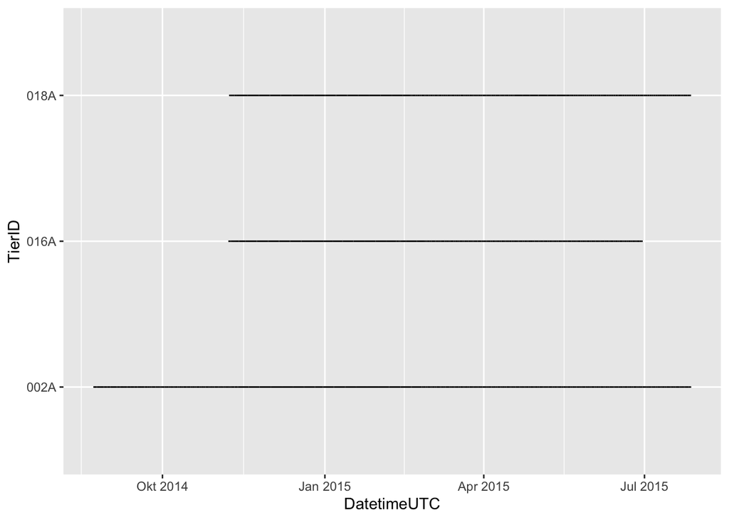

```r
ggplot(wildschwein_BE, aes(DatetimeUTC, TierID)) +
  geom_line()
```

What is the temporal sampling interval between the locations?

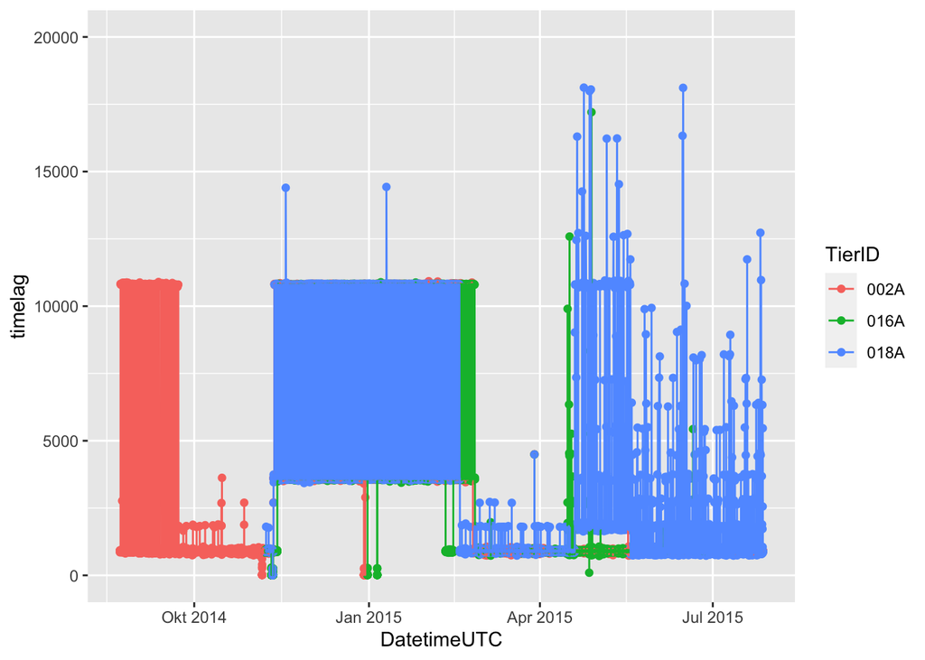

```r
ggplot(wildschwein_BE, aes(DatetimeUTC, timelag, colour = TierID)) +
  ylim(0, 20000) +
  geom_point() +
  geom_line()
```

# Task 3: Deriving movement parameters I: Speed

```r
n=dim(wildschwein_BE)[1] #or
n=51247

E1=wildschwein_BE$E[1:(n-1)]
E2=wildschwein_BE$E[2:n]
N1=wildschwein_BE$N[1:(n-1)]
N2=wildschwein_BE$N[2:n]
dist=sqrt((E1-E2)^2+(N1-N2)^2)
wildschwein_BE$steplenght <- dist
wildschwein_BE$speed <- dist/wildschwein_BE$timelag
```

# Task 4: Cross-scale movement analysis

Import file

```r
caro <- read_delim("caro60.csv",",")
caro <- st_as_sf(caro, coords = c("E", "N"), remove = FALSE)
```

Reduce the granularity of our sampling interval by selecting every 3rd, 6th and 9th position

```r
caro_3<- caro %>% dplyr::slice(seq(1, nrow(.),3))
caro_6<- caro %>% dplyr::slice(seq(1, nrow(.),6))
caro_9<- caro %>% dplyr::slice(seq(1, nrow(.),9))

nrow(caro)
```

```
## [1] 200
```

```r
nrow(caro_3)
```

```
## [1] 67
```

```r
nrow(caro_6)
```

```
## [1] 34
```

```r
nrow(caro_9)
```

```
## [1] 23
```

Calculate Timelag / Stephlength / Speed

```r
caro <- caro %>%
  group_by(TierID) %>%
  mutate(timelag = as.integer(difftime(lead(DatetimeUTC),DatetimeUTC, units="secs"))) %>%
  mutate(steplength = sqrt(((E-lead(E,1))^2) + ((N-lead(N,1))^2))) %>%
  mutate(speed = steplength/timelag)

caro_3 <- caro_3 %>%
  group_by(TierID) %>%
  mutate(timelag = as.integer(difftime(lead(DatetimeUTC),DatetimeUTC, units="secs"))) %>%
  mutate(steplength = sqrt(((E-lead(E,1))^2) + ((N-lead(N,1))^2))) %>%
  mutate(speed = steplength/timelag)

caro_6 <- caro_6 %>%
  group_by(TierID) %>%
  mutate(timelag = as.integer(difftime(lead(DatetimeUTC),DatetimeUTC, units="secs"))) %>%
  mutate(steplength = sqrt(((E-lead(E,1))^2) + ((N-lead(N,1))^2))) %>%
  mutate(speed = steplength/timelag)

caro_9 <- caro_9 %>%
  group_by(TierID) %>%
  mutate(timelag = as.integer(difftime(lead(DatetimeUTC),DatetimeUTC, units="secs"))) %>%
  mutate(steplength = sqrt(((E-lead(E,1))^2) + ((N-lead(N,1))^2))) %>%
  mutate(speed = steplength/timelag)
```

Visualize the trajectories in a map

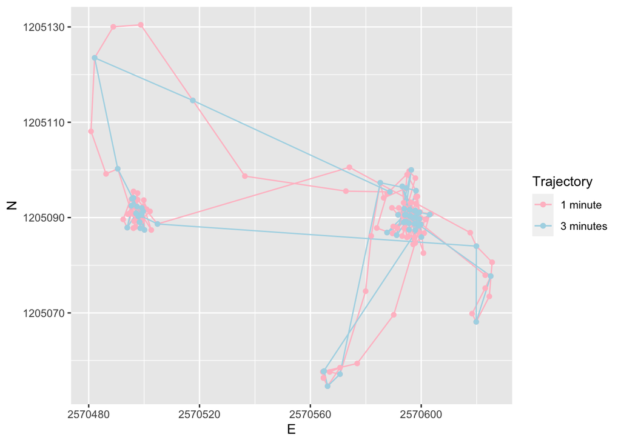

```r
ggplot() +
  geom_path(data=caro, aes(x = E, y = N, colour = "1 minute"))+
  geom_path(data=caro_3, aes(x = E,y = N, color = "3 minutes")) +
  geom_point(data=caro, aes(x = E, y = N, colour = "1 minute")) +
  geom_point(data=caro_3, aes(x = E, y = N, colour = "3 minutes")) +
  theme(legend.position = "right") +
  scale_color_manual(name='Trajectory',
                     breaks=c('1 minute', '3 minutes'),
                     values=c('1 minute'='pink', '3 minutes'='lightblue'))
```

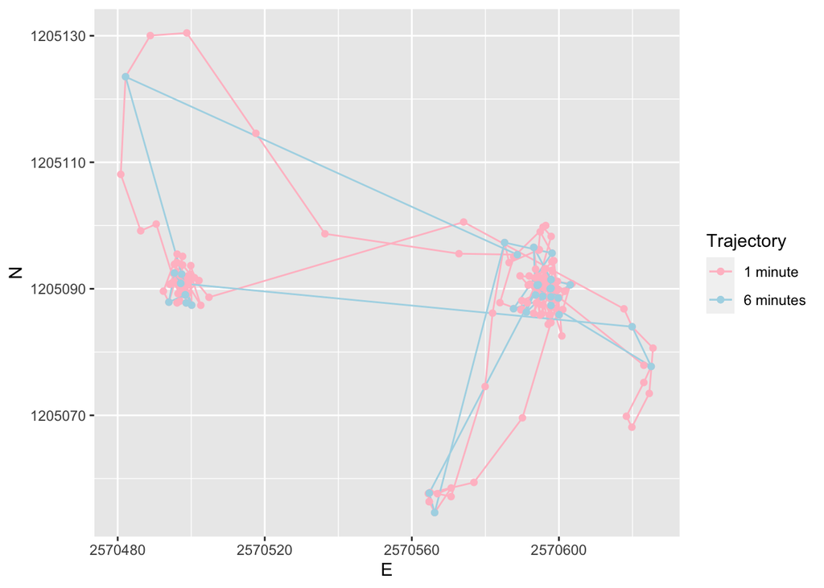

```r
ggplot() +
  geom_path(data=caro, aes(x = E, y = N, colour = "1 minute"))+
  geom_path(data=caro_6, aes(x = E,y = N, color = "6 minutes")) +
  geom_point(data=caro, aes(x = E, y = N, colour = "1 minute")) +
  geom_point(data=caro_6, aes(x = E, y = N, colour = "6 minutes")) +
  theme(legend.position = "right") +
  scale_color_manual(name='Trajectory',
                     breaks=c('1 minute', '6 minutes'),
                     values=c('1 minute'='pink', '6 minutes'='lightblue'))
```

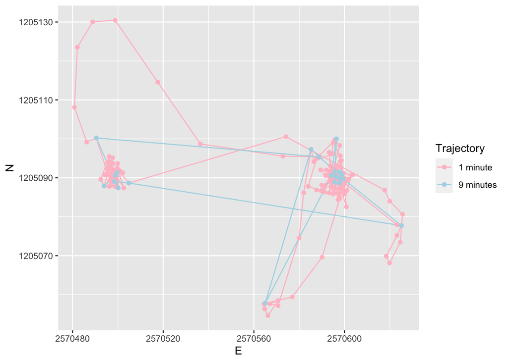

```r
ggplot() +
  geom_path(data=caro, aes(x = E, y = N, colour = "1 minute"))+
  geom_path(data=caro_9, aes(x = E,y = N, color = "9 minutes")) +
  geom_point(data=caro, aes(x = E, y = N, colour = "1 minute")) +
  geom_point(data=caro_9, aes(x = E, y = N, colour = "9 minutes")) +
  theme(legend.position = "right") +
  scale_color_manual(name='Trajectory',
                     breaks=c('1 minute', '9 minutes'),
                     values=c('1 minute'='pink', '9 minutes'='lightblue'))
```

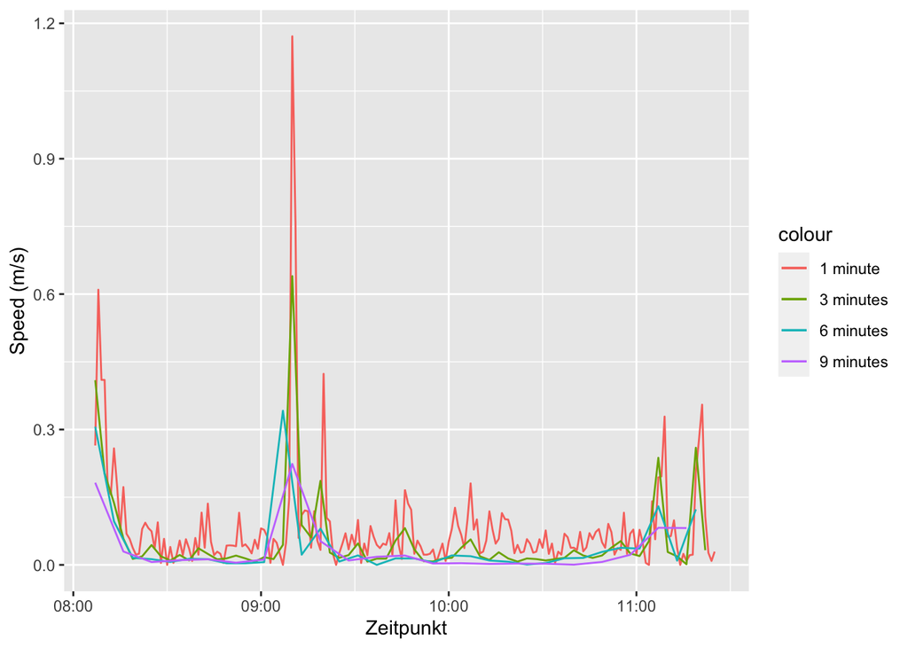

```r
ggplot() +
  geom_line(data=caro, aes(x = DatetimeUTC, y = speed, color= "1 minute")) +
  geom_line(data=caro_3, aes(x = DatetimeUTC, y = speed, color= "3 minutes")) +
  geom_line(data=caro_6, aes(x = DatetimeUTC, y = speed, color= "6 minutes")) +
  geom_line(data=caro_9, aes(x = DatetimeUTC, y = speed, color= "9 minutes")) +
  labs(x="Zeitpunkt",y="Speed (m/s)")
```

# Task 5: Deriving movement parameters II: Rolling window functions

```r
library(zoo)
example <- rnorm(10)
rollmean(example,k = 3,fill = NA,align = "left")
```

```
##  [1]  0.2097570  0.9154605  0.6307414 -0.4160102 -0.5019336 -0.2926127
##  [7] -0.3788860 -1.0124835         NA         NA
```

```r
rollmean(example,k = 4,fill = NA,align = "left")
```

```
##  [1]  0.3490944  0.4077752  0.2480918 -0.1846735 -0.4982797 -0.5091287
##  [7] -0.6320285         NA         NA         NA
```

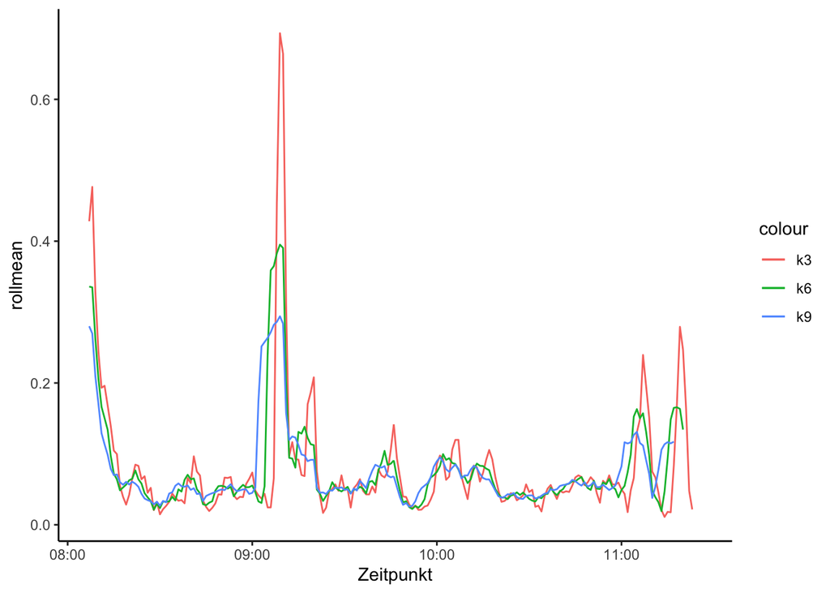

```r
caro$k3<- rollmean(caro$speed,k = 3,fill = NA,align = "left")
caro$k6<- rollmean(caro$speed,k = 6,fill = NA,align = "left")
caro$k9<- rollmean(caro$speed,k = 9,fill = NA,align = "left")

ggplot() +
  geom_path(data=caro, aes(x = DatetimeUTC, y = k3, color= "k3"))+
  geom_path(data=caro, aes(x = DatetimeUTC, y = k6, color= "k6"))+
  geom_path(data=caro, aes(x = DatetimeUTC, y = k9, color= "k9"))+
  theme_classic() +
  labs(x="Zeitpunkt",y="rollmean")
```